# Exploring nested mixed models in RR

## Normalize by total count per sample

**Phyloseq** function **transform_sample_counts()** allows applying a function over samples. The function takes the **x** argument, which refers to a **column** within the feature table (remember: taxa= rows, samples=columns).

**transform_sample_counts()** may be used for normalization, such as scaling or centering per sample.

For simplicity, in this tutorial we will **normalize by total count per sample**. Then we scale the fractions by the median, and round to integers because some of the downstream functions expect integer counts, rather than fractions.

An alternative commonly used way of normalizing microbial data is **rarefaction**: equalizing depth in samples by random removal of data from the samples with higher depth. In R, the rarefaction curves could be plottred using **vegan::rarecurve()**, then the rarefaction may be applied using **phyloseq::rarefy_even_depth()**.

It’s important to remember that after combining samples or filtering taxa the normalization should be repeated.

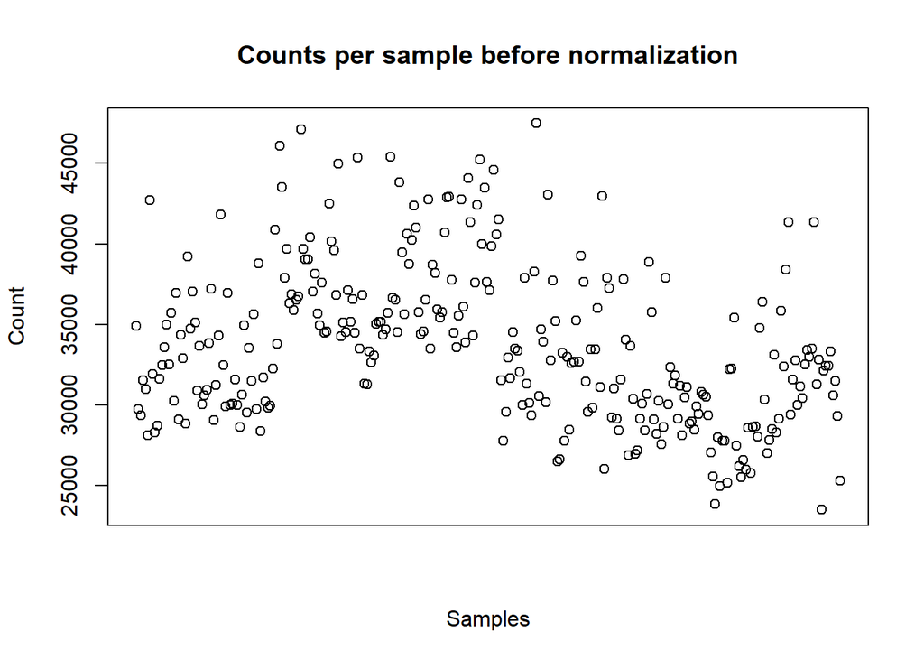

```r
# Counts per sample before normalization
plot(colSums(otu_table(BacIndAgriClassAbund.phy)),
     ylab="Count", xlab="Samples", xaxt="n",
     main="Counts per sample before normalization")
```

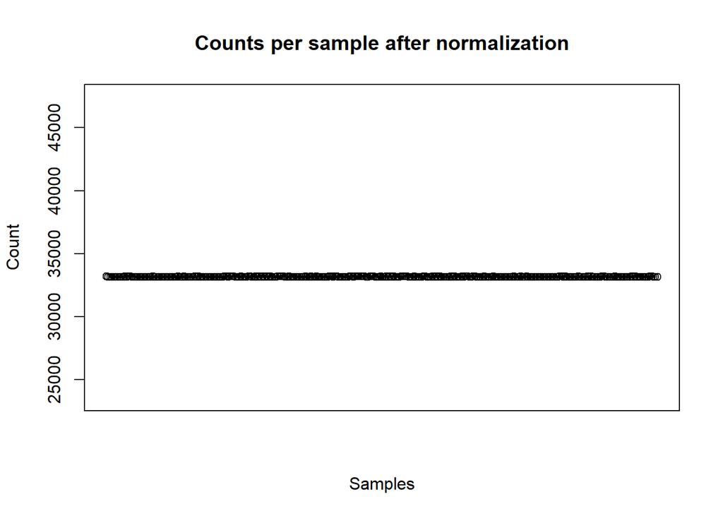

```r
# Calculate median count per sample before normalization (33,183)
countsPerSample <- colSums(otu_table(BacIndAgriClassAbund.phy))
medianCount <- median(countsPerSample)

# Normalize by total count per sample
BacIndAgriClassAbundNorm.phy  = transform_sample_counts(BacIndAgriClassAbund.phy,
  function(x) x / sum(x))

# Scale and round (to have integer counts instead of fractions)
BacIndAgriClassAbundNorm.phy  = transform_sample_counts(BacIndAgriClassAbundNorm.phy,
  function(x) round(x*medianCount))

# Counts per sample after normalization
plot(colSums(otu_table(BacIndAgriClassAbundNorm.phy)),
     ylab="Count", xlab="Samples", xaxt="n",
     main="Counts per sample after normalization",
     ylim=c(min(countsPerSample),max(countsPerSample)))
```

```r
# Clean-up
rm(BacIndAgriClassAbund.phy, countsPerSample, medianCount)
```

# Alpha diversity

**Alpha diversity** describes the richness and/or evenness of microbial community within a single sample.

## Plots

There are many measures of **Alpha diversity**. Here we plot *Shannon* and *Simpson* indices only.

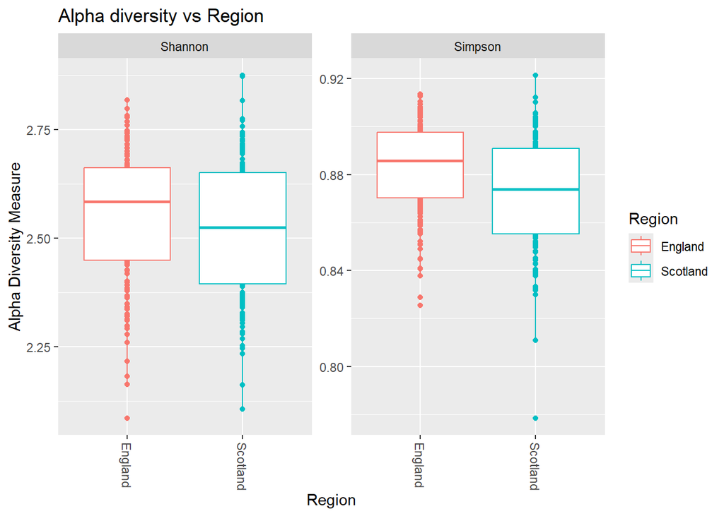

```r
plot_richness(BacIndAgriClassAbundNorm.phy,
              measures=c("Shannon", "Simpson"),
              color="Region", x="Region",
              title="Alpha diversity vs Region") +
  geom_boxplot()
```

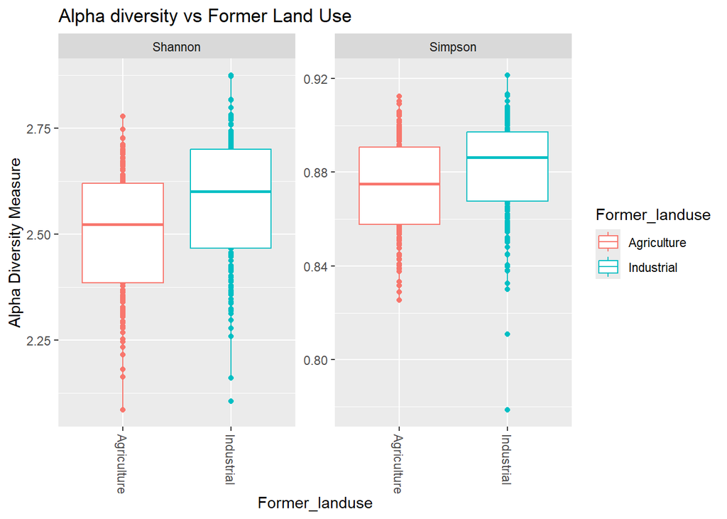

```r
plot_richness(BacIndAgriClassAbundNorm.phy,
              measures=c("Shannon", "Simpson"),
              color="Former_landuse", x="Former_landuse",
              title="Alpha diversity vs Former Land Use") +
  geom_boxplot()
```

## Estimating statistical significance

Here we will explore different statistical models to estimate what factors may affect the Shannon diversity.  
Visual assessment of the plots suggests that alpha diversity may depend on the former land use and region.

In general, the statistical modelling should account for study design and for sparsity/compositionality of the data.

The design may include mixed model, nesting and croissing the factors.

Because of the **compositionality** (relative nature) and high **sparsity** of the standard statistical tests assuming normality of distributions usually are not appropriate for microbial data. Instead, it is recommended to use **non-parametric** tests (or specialized and **permutation-based** tests).

### Prepare data

```r
# Calculate Alpha diversity indices
alpha_richness.df = estimate_richness(
  BacIndAgriClassAbundNorm.phy, measures = c("Shannon", "Simpson"))

head(alpha_richness.df)
```

```
##        Shannon   Simpson
## WP001 2.344960 0.8547996
## WP002 2.392025 0.8640416
## WP003 2.420025 0.8390369
## WP004 2.682299 0.8971910
## WP005 2.712531 0.8952492
## WP006 2.310005 0.8427377
```

```r
# Extract metadata from phyloseq object
data.df <- data.frame(sample_data(BacIndAgriClassAbundNorm.phy))

# Explore and reformat data
data.df <- data.df %>%
  select(Region,
         Use=Former_landuse,
         Site=Site_code,
         Plot=Site_Code_Plot,
         Age=Woodland_age,
         pH, Conductivity)

str(data.df)
```

```
## 'data.frame':    300 obs. of  7 variables:
##  $ Region      : chr  "Scotland" "Scotland" "Scotland" "Scotland" ...
##  $ Use         : chr  "Agriculture" "Agriculture" "Agriculture" "Agriculture" ...
##  $ Site        : chr  "SW01" "SW01" "SW01" "SW01" ...
##  $ Plot        : chr  "SW01_P1" "SW01_P2" "SW01_P3" "SW01_P4" ...
##  $ Age         : int  18 18 18 18 18 50 50 50 50 50 ...
##  $ pH          : chr  "5.04" "5.04" "5.04" "5.04" ...
##  $ Conductivity: chr  "63.7" "63.7" "63.7" "63.7" ...
```

```r
sum(is.na(data.df$pH))
```

```
## [1] 0
```

```r
sum(is.na(data.df$Conductivity))
```

```
## [1] 0
```

```r
data.df$pH <- as.numeric(data.df$pH) # 5 missed data points
data.df$Conductivity <- as.numeric(data.df$Conductivity) # 5 missed data points

# Add Shannon diversity
all(rownames(data.df) == rownames(alpha_richness.df))
```

```
## [1] TRUE
```

```r
data.df <- data.frame(Shannon=alpha_richness.df$Shannon, data.df)

# Explore result
str(data.df)
```

```
## 'data.frame':    300 obs. of  8 variables:
##  $ Shannon     : num  2.34 2.39 2.42 2.68 2.71 ...
##  $ Region      : chr  "Scotland" "Scotland" "Scotland" "Scotland" ...
##  $ Use         : chr  "Agriculture" "Agriculture" "Agriculture" "Agriculture" ...
##  $ Site        : chr  "SW01" "SW01" "SW01" "SW01" ...
##  $ Plot        : chr  "SW01_P1" "SW01_P2" "SW01_P3" "SW01_P4" ...
##  $ Age         : int  18 18 18 18 18 50 50 50 50 50 ...
##  $ pH          : num  5.04 5.04 5.04 5.04 5.04 4.85 4.85 4.85 4.85 4.85 ...
##  $ Conductivity: num  63.7 63.7 63.7 63.7 63.7 33.4 33.4 33.4 33.4 33.4 ...
```

```r
head(data.df)
```

```
##        Shannon   Region         Use Site    Plot Age   pH Conductivity
## WP001 2.344960 Scotland Agriculture SW01 SW01_P1  18 5.04         63.7
## WP002 2.392025 Scotland Agriculture SW01 SW01_P2  18 5.04         63.7
## WP003 2.420025 Scotland Agriculture SW01 SW01_P3  18 5.04         63.7
## WP004 2.682299 Scotland Agriculture SW01 SW01_P4  18 5.04         63.7
## WP005 2.712531 Scotland Agriculture SW01 SW01_P5  18 5.04         63.7
## WP006 2.310005 Scotland Agriculture SW02 SW02_P1  50 4.85         33.4
```

```r
tail(data.df)
```

```
##        Shannon   Region        Use Site    Plot Age   pH Conductivity
## WP625 2.769508  England Industrial EW30 EW30_P5  57 7.79        174.9
## WP656 2.695084 Scotland Industrial SW17 SW17_P1  28   NA           NA
## WP657 2.712512 Scotland Industrial SW17 SW17_P2  28   NA           NA
## WP658 2.774860 Scotland Industrial SW17 SW17_P3  28   NA           NA
## WP659 2.713831 Scotland Industrial SW17 SW17_P4  28   NA           NA
## WP660 2.663982 Scotland Industrial SW17 SW17_P5  28   NA           NA
```

```r
# Clean-up
rm(alpha_richness.df)
```

### Wilcoxon test

```r
wilcox.test(Shannon~Region, data=data.df)
```

```
##
##  Wilcoxon rank sum test with continuity correction
##
## data:  Shannon by Region
## W = 12698, p-value = 0.05401
## alternative hypothesis: true location shift is not equal to 0
```

```r
wilcox.test(Shannon~Use, data=data.df)
```

```
##
##  Wilcoxon rank sum test with continuity correction
##
## data:  Shannon by Use
## W = 8159, p-value = 3.892e-05
## alternative hypothesis: true location shift is not equal to 0
```

### Mixed models

In general, the highly significant non-parametric Wilcoxon test could be considered sufficient for confirming that alpha diversity changes depending on the land use. However, mixed models may be better suited for the RestREco design to account for uncertainty between the replicas within each site:

https://www.modernstatisticswithr.com/regression.html#mixedmodels

Here mixed models with lme4 are calculated for Shannon diversity. The mixed models could also be applied to pH and conductivity analysis. Here we just explore different options. The final design of mixed effects modelling will be further discussed with local experts in statistical modelling (Ronald Corstanje and Alice Johnston),

Later we may also try to apply mixed models to the soil community composition (beta diversity). However, adonis2 does not accept the lme4 syntax. So, we will need to consider using restricted permutations and modifying the distances calculations instead of using the extended R formula syntax?

**Compare mixed models using syntax as implemented in lme4 package**

```r
library(lme4)
library(lmerTest)

fit1 <- lmer(Shannon ~ Region/Use + (1|Site), data=data.df)
summary(fit1)
```

```
## Linear mixed model fit by REML. t-tests use Satterthwaite's method ['lmerModLmerTest']
## Formula: Shannon ~ Region/Use + (1 | Site)
##    Data: data.df
##
## REML criterion at convergence: -420.4
##
## Scaled residuals:
##      Min       1Q   Median       3Q      Max
## -3.09241 -0.47308 -0.00248  0.54335  2.98818
##
## Random effects:
##  Groups   Name        Variance Std.Dev.
##  Site     (Intercept) 0.013807 0.11750
##  Residual             0.008843 0.09404
## Number of obs: 300, groups:  Site, 60
##
## Fixed effects:
##                              Estimate Std. Error       df t value Pr(>|t|)
## (Intercept)                   2.52611    0.03222 55.99996  78.392   <2e-16 ***
## RegionScotland               -0.04638    0.04557 55.99996  -1.018   0.3132
## RegionEngland:UseIndustrial   0.05834    0.04557 55.99996   1.280   0.2057
## RegionScotland:UseIndustrial  0.08664    0.04557 55.99996   1.901   0.0624 .
## ---
## Signif. codes:  0 '***' 0.001 '**' 0.01 '*' 0.05 '.' 0.1 ' ' 1
##
## Correlation of Fixed Effects:
##             (Intr) RgnSct RgE:UI
## ReginSctlnd -0.707
## RgnEngln:UI -0.707  0.500
## RgnSctln:UI  0.000 -0.500  0.000
```

```r
anova(fit1)
```

```
## Type III Analysis of Variance Table with Satterthwaite's method
##              Sum Sq   Mean Sq NumDF DenDF F value  Pr(>F)
## Region     0.009160 0.0091601     1    56  1.0358 0.31318
## Region:Use 0.046457 0.0232285     2    56  2.6266 0.08122 .
## ---
## Signif. codes:  0 '***' 0.001 '**' 0.01 '*' 0.05 '.' 0.1 ' ' 1
```

```r
fit2 <- lmer(Shannon ~ Region + Use + (1|Site), data=data.df)
summary(fit2)
```

```
## Linear mixed model fit by REML. t-tests use Satterthwaite's method ['lmerModLmerTest']
## Formula: Shannon ~ Region + Use + (1 | Site)
##    Data: data.df
##
## REML criterion at convergence: -423.9
##
## Scaled residuals:
##      Min       1Q   Median       3Q      Max
## -3.08706 -0.47970 -0.00018  0.54786  2.97825
##
## Random effects:
##  Groups   Name        Variance Std.Dev.
##  Site     (Intercept) 0.013587 0.11656
##  Residual             0.008843 0.09404
## Number of obs: 300, groups:  Site, 60
##
## Fixed effects:
##                Estimate Std. Error       df t value Pr(>|t|)
## (Intercept)     2.51903    0.02771 56.99996  90.911   <2e-16 ***
## RegionScotland -0.03223    0.03200 56.99996  -1.007   0.3180
## UseIndustrial   0.07249    0.03200 56.99996   2.266   0.0273 *
## ---
## Signif. codes:  0 '***' 0.001 '**' 0.01 '*' 0.05 '.' 0.1 ' ' 1
##
## Correlation of Fixed Effects:
##             (Intr) RgnSct
## ReginSctlnd -0.577
## UseIndustrl -0.577  0.000
```

```r
anova(fit2)
```

```
## Type III Analysis of Variance Table with Satterthwaite's method
##          Sum Sq  Mean Sq NumDF DenDF F value  Pr(>F)
## Region 0.008975 0.008975     1    57  1.0149 0.31799
## Use    0.045395 0.045395     1    57  5.1332 0.02729 *
## ---
## Signif. codes:  0 '***' 0.001 '**' 0.01 '*' 0.05 '.' 0.1 ' ' 1
```

```r
fit3 <- lmer(Shannon ~ Use + (1|Site), data=data.df)
summary(fit3)
```

```
## Linear mixed model fit by REML. t-tests use Satterthwaite's method ['lmerModLmerTest']
## Formula: Shannon ~ Use + (1 | Site)
##    Data: data.df
##
## REML criterion at convergence: -427.9
##
## Scaled residuals:
##      Min       1Q   Median       3Q      Max
## -3.10673 -0.48956  0.01062  0.56084  2.95854
##
## Random effects:
##  Groups   Name        Variance Std.Dev.
##  Site     (Intercept) 0.013591 0.11658
##  Residual             0.008843 0.09404
## Number of obs: 300, groups:  Site, 60
##
## Fixed effects:
##               Estimate Std. Error       df t value Pr(>|t|)
## (Intercept)    2.50292    0.02263 57.99996 110.617   <2e-16 ***
## UseIndustrial  0.07249    0.03200 57.99996   2.265   0.0272 *
## ---
## Signif. codes:  0 '***' 0.001 '**' 0.01 '*' 0.05 '.' 0.1 ' ' 1
##
## Correlation of Fixed Effects:
##             (Intr)
## UseIndustrl -0.707
```

```r
anova(fit3)
```

```
## Type III Analysis of Variance Table with Satterthwaite's method
##       Sum Sq  Mean Sq NumDF DenDF F value  Pr(>F)
## Use 0.045383 0.045383     1    58  5.1319 0.02724 *
## ---
## Signif. codes:  0 '***' 0.001 '**' 0.01 '*' 0.05 '.' 0.1 ' ' 1
```

```r
fit4 <- lmer(Shannon ~ Region/Use + pH + (1|Site), data=data.df)
summary(fit4)
```

```
## Linear mixed model fit by REML. t-tests use Satterthwaite's method ['lmerModLmerTest']
## Formula: Shannon ~ Region/Use + pH + (1 | Site)
##    Data: data.df
##
## REML criterion at convergence: -436.1
##
## Scaled residuals:
##     Min      1Q  Median      3Q     Max
## -3.2483 -0.4963 -0.0094  0.5527  2.9293
##
## Random effects:
##  Groups   Name        Variance Std.Dev.
##  Site     (Intercept) 0.006945 0.08334
##  Residual             0.008966 0.09469
## Number of obs: 295, groups:  Site, 59
##
## Fixed effects:
##                               Estimate Std. Error        df t value Pr(>|t|)
## (Intercept)                   1.994485   0.084393 53.999993  23.633  < 2e-16 ***
## RegionScotland                0.001735   0.034910 53.999993   0.050    0.961
## pH                            0.092650   0.014093 53.999993   6.574 2.02e-08 ***
## RegionEngland:UseIndustrial   0.004358   0.035108 53.999993   0.124    0.902
## RegionScotland:UseIndustrial  0.028328   0.035494 53.999993   0.798    0.428
## ---
## Signif. codes:  0 '***' 0.001 '**' 0.01 '*' 0.05 '.' 0.1 ' ' 1
##
## Correlation of Fixed Effects:
##             (Intr) RgnSct pH     RgE:UI
## ReginSctlnd -0.399
## pH          -0.958  0.210
## RgnEngln:UI  0.028  0.426 -0.234
## RgnSctln:UI  0.197 -0.513 -0.205  0.048
```

```r
anova(fit4)
```

```
## Type III Analysis of Variance Table with Satterthwaite's method
##             Sum Sq Mean Sq NumDF DenDF F value    Pr(>F)
## Region     0.00002 0.00002     1    54  0.0025    0.9605
## pH         0.38747 0.38747     1    54 43.2174 2.023e-08 ***
## Region:Use 0.00578 0.00289     2    54  0.3222    0.7260
## ---
## Signif. codes:  0 '***' 0.001 '**' 0.01 '*' 0.05 '.' 0.1 ' ' 1
```

```r
fit5 <- lmer(Shannon ~ Region/Use + Age + (1|Site), data=data.df)
summary(fit5)
```

```
## Linear mixed model fit by REML. t-tests use Satterthwaite's method ['lmerModLmerTest']
## Formula: Shannon ~ Region/Use + Age + (1 | Site)
##    Data: data.df
##
## REML criterion at convergence: -408.6
##
## Scaled residuals:
##     Min      1Q  Median      3Q     Max
## -3.0869 -0.4673  0.0003  0.5441  2.9800
##
## Random effects:
##  Groups   Name        Variance Std.Dev.
##  Site     (Intercept) 0.014044 0.11851
##  Residual             0.008843 0.09404
## Number of obs: 300, groups:  Site, 60
##
## Fixed effects:
##                                Estimate Std. Error         df t value Pr(>|t|)
## (Intercept)                   2.5113819  0.0490195 54.9999684  51.232   <2e-16 ***
## RegionScotland               -0.0466225  0.0459213 54.9999686  -1.015   0.3144
## Age                           0.0004031  0.0010052 54.9999685   0.401   0.6900
## RegionEngland:UseIndustrial   0.0582076  0.0459185 54.9999686   1.268   0.2103
## RegionScotland:UseIndustrial  0.0853486  0.0460298 54.9999686   1.854   0.0691 .
## ---
## Signif. codes:  0 '***' 0.001 '**' 0.01 '*' 0.05 '.' 0.1 ' ' 1
##
## Correlation of Fixed Effects:
##             (Intr) RgnSct Age    RgE:UI
## ReginSctlnd -0.458
## Age         -0.749 -0.013
## RgnEngln:UI -0.463  0.500 -0.007
## RgnSctln:UI  0.052 -0.498 -0.070  0.001
```

```r
anova(fit5)
```

```
## Type III Analysis of Variance Table with Satterthwaite's method
##              Sum Sq   Mean Sq NumDF DenDF F value  Pr(>F)
## Region     0.009116 0.0091156     1    55  1.0308 0.31442
## Age        0.001422 0.0014221     1    55  0.1608 0.68997
## Region:Use 0.044593 0.0222967     2    55  2.5213 0.08961 .
## ---
## Signif. codes:  0 '***' 0.001 '**' 0.01 '*' 0.05 '.' 0.1 ' ' 1
```

```r
fit6 <- lmer(Shannon ~ Region/Use + Age + pH + (1|Site), data=data.df)
summary(fit6)
```

```
## Linear mixed model fit by REML. t-tests use Satterthwaite's method ['lmerModLmerTest']
## Formula: Shannon ~ Region/Use + Age + pH + (1 | Site)
##    Data: data.df
##
## REML criterion at convergence: -423.5
##
## Scaled residuals:
##     Min      1Q  Median      3Q     Max
## -3.2402 -0.4947 -0.0044  0.5471  2.9291
##
## Random effects:
##  Groups   Name        Variance Std.Dev.
##  Site     (Intercept) 0.007109 0.08432
##  Residual             0.008966 0.09469
## Number of obs: 295, groups:  Site, 59
##
## Fixed effects:
##                               Estimate Std. Error        df t value Pr(>|t|)
## (Intercept)                  1.993e+00  8.749e-02 5.300e+01  22.781  < 2e-16 ***
## RegionScotland               1.647e-03  3.525e-02 5.300e+01   0.047    0.963
## Age                          5.761e-05  7.617e-04 5.300e+01   0.076    0.940
## pH                           9.255e-02  1.429e-02 5.300e+01   6.476 3.14e-08 ***
## RegionEngland:UseIndustrial  4.399e-03  3.544e-02 5.300e+01   0.124    0.902
## RegionScotland:UseIndustrial 2.815e-02  3.591e-02 5.300e+01   0.784    0.437
## ---
## Signif. codes:  0 '***' 0.001 '**' 0.01 '*' 0.05 '.' 0.1 ' ' 1
##
## Correlation of Fixed Effects:
##             (Intr) RgnSct Age    pH     RgE:UI
## ReginSctlnd -0.380
## Age         -0.228 -0.033
## pH          -0.907  0.212 -0.096
## RgnEngln:UI  0.023  0.425  0.015 -0.234
## RgnSctln:UI  0.206 -0.510 -0.067 -0.197  0.047
```

```r
anova(fit6)
```

```
## Type III Analysis of Variance Table with Satterthwaite's method
##             Sum Sq Mean Sq NumDF DenDF F value    Pr(>F)
## Region     0.00002 0.00002     1    53  0.0022    0.9629
## Age        0.00005 0.00005     1    53  0.0057    0.9400
## pH         0.37598 0.37598     1    53 41.9357 3.141e-08 ***
## Region:Use 0.00558 0.00279     2    53  0.3111    0.7340
## ---
## Signif. codes:  0 '***' 0.001 '**' 0.01 '*' 0.05 '.' 0.1 ' ' 1
```

```r
fit7 <- lmer(Shannon ~ Region/Use + Age + pH + Conductivity + (1|Site), data=data.df)
summary(fit7)
```

```
## Linear mixed model fit by REML. t-tests use Satterthwaite's method ['lmerModLmerTest']
## Formula: Shannon ~ Region/Use + Age + pH + Conductivity + (1 | Site)
##    Data: data.df
##
## REML criterion at convergence: -413.4
##
## Scaled residuals:
##     Min      1Q  Median      3Q     Max
## -3.2218 -0.5026  0.0094  0.5671  2.9247
##
## Random effects:
##  Groups   Name        Variance Std.Dev.
##  Site     (Intercept) 0.006566 0.08103
##  Residual             0.008966 0.09469
## Number of obs: 295, groups:  Site, 59
##
## Fixed effects:
##                                Estimate Std. Error         df t value Pr(>|t|)
## (Intercept)                   1.9966694  0.0847950 51.9999925  23.547  < 2e-16 ***
## RegionScotland                0.0435206  0.0395224 51.9999923   1.101   0.2759
## Age                          -0.0002917  0.0007565 51.9999923  -0.386   0.7014
## pH                            0.0814865  0.0148098 51.9999924   5.502 1.16e-06 ***
## Conductivity                  0.0006158  0.0002923 51.9999923   2.107   0.0399 *
## RegionEngland:UseIndustrial  -0.0055161  0.0346633 51.9999923  -0.159   0.8742
## RegionScotland:UseIndustrial  0.0342039  0.0349125 51.9999923   0.980   0.3318
## ---
## Signif. codes:  0 '***' 0.001 '**' 0.01 '*' 0.05 '.' 0.1 ' ' 1
##
## Correlation of Fixed Effects:
##             (Intr) RgnSct Age    pH     Cndctv RgE:UI
## ReginSctlnd -0.318
## Age         -0.227 -0.138
## pH          -0.855 -0.007 -0.010
## Conductivty  0.021  0.503 -0.219 -0.354
## RgnEngln:UI  0.020  0.296  0.045 -0.169 -0.136
## RgnSctln:UI  0.207 -0.398 -0.083 -0.213  0.082  0.035
```

```r
anova(fit7)
```

```
## Type III Analysis of Variance Table with Satterthwaite's method
##                Sum Sq  Mean Sq NumDF DenDF F value    Pr(>F)
## Region       0.010871 0.010871     1    52  1.2126   0.27590
## Age          0.001333 0.001333     1    52  0.1486   0.70140
## pH           0.271426 0.271426     1    52 30.2742 1.162e-06 ***
## Conductivity 0.039811 0.039811     1    52  4.4404   0.03994 *
## Region:Use   0.008942 0.004471     2    52  0.4987   0.61022
## ---
## Signif. codes:  0 '***' 0.001 '**' 0.01 '*' 0.05 '.' 0.1 ' ' 1
```

```r
# Clean-up
rm(fit1,fit2, fit3, fit4, fit5, fit6, fit7)
```

# Beta diversity

Beta diversity is often illustrated by plots showing unconstrained ordination of samples.

Term “**ordination**” in ecology is used for **dimentionality reduction** and visualization techniques (similar to PCA). The idea is to make a 2D (or 3D) image that would reflect similarity/distances between samples (or taxa). The plot should show similar samples (or taxa) close to each other, while the dissimilar samples (or taxa) should be drown far apart.

## Plotting

### Calculating unconstrained ordination

Technically, an (*unconstrained*) ordination procedure includes two main steps:

- calculating distances between samples, and
- making a plot to reflect these distances in 2D image in a best possible way.

In the example below we use **Bray-Curtis** distance and **PCoA** method for making the plot. See help to the **ordinate()** function (**?ordinate**) to find information about other available distances and methods.

Here we consider the *unconstrained* ordination only. The *constrained* ordination includes additional steps, which allow adding some environmental gradients (e.g. soil pH) to the plot: so we can see how the samples & taxa are positioned along these gradients.

```r
ord <- ordinate(BacIndAgriClassAbundNorm.phy,
                distance = "bray",
                method = "PCoA")
```

### Plotting with Phyloseq

**Beta diversity**, in effect, is an unconstrained ordination of **samples**. The samples located closely on the plot have similar microbial communities, the samples located far apart have very distinct microbial communities.

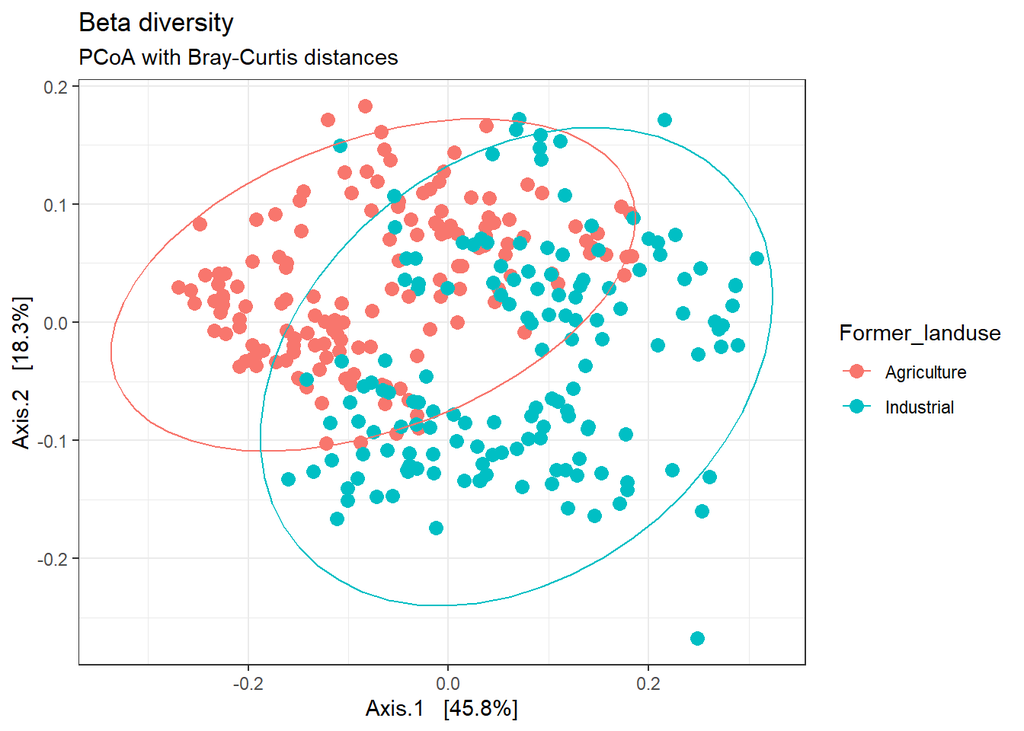

```r
plot_ordination(BacIndAgriClassAbundNorm.phy, ord, type="samples",
                color="Former_landuse") + geom_point(size=3) +
  stat_ellipse() +
  ggtitle("Beta diversity",
          subtitle="PCoA with Bray-Curtis distances")+
  theme_bw()
```

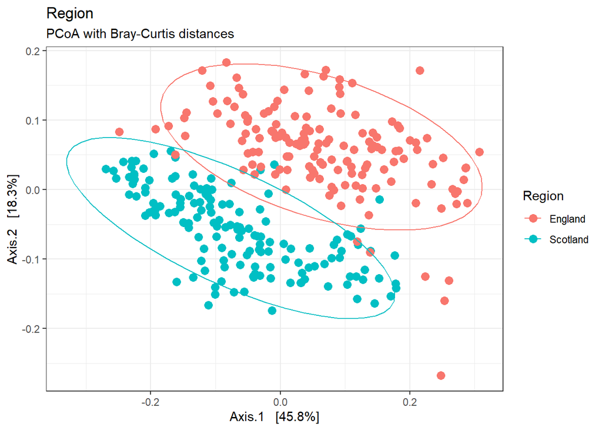

```r
plot_ordination(BacIndAgriClassAbundNorm.phy, ord, type="samples",
                color="Region") + geom_point(size=3) +
  stat_ellipse() +
  ggtitle("Region",
          subtitle="PCoA with Bray-Curtis distances")+
  theme_bw()
```

```r
# Clean-up
rm(ord)
```

## Evaluating statisitcal significance

### Calculate distance matrix with Phyloseq

```r
bray.dist <- distance(BacIndAgriClassAbundNorm.phy, method="bray")
as.matrix(bray.dist)[1:5,1:5]
```

```
##            WP001      WP002     WP003      WP004      WP005
## WP001 0.00000000 0.09555522 0.2874471 0.21405539 0.18252772
## WP002 0.09555522 0.00000000 0.2352294 0.15354710 0.16339692
## WP003 0.28744707 0.23522941 0.0000000 0.18898148 0.19497310
## WP004 0.21405539 0.15354710 0.1889815 0.00000000 0.07829782
## WP005 0.18252772 0.16339692 0.1949731 0.07829782 0.00000000
```

### PERMANOVA with Vegan::Adonis2

Judging by the **Beta diversity** plots the soil communities are quite different depending on the region or prior use.

As it was noted earlier, the microbial data requires specialized tests. The most commonly used test for estimating **Beta diversity** statistical significance is **PERMANOVA** (PERmutation based Multivariate ANOVA) implemented in **adonis2()** function from the **vegan** package.

In the example below you may note this formula within the **vegan::adonis2()** function:  
**~Region/Use/Site**.  
This is a way of describing multi-layer nested designs in R.

Also, you may note the **strata=Region** term: it does not allow permutations between regions.

The modelling shows that the microbial communities are very different  
- between the studied regions, and  
- between the land use types within each region, and  
- between the sites for each land use within each region.

However, this formula considers all the factors as fixed, and does not account for the mixed effect design. Unfortunately, adonis2 does not understand the lme4 syntax. So, we will have to find a way of how to achieve mixed effects effect using restricted permutations and distance calculations. Googling **mixed models adonis2** finds a number of discussions about it. Some references about **restricted permutations** and **nested designs** are given later.

```r
library(vegan)

# This lmer mixed model syntax fails in adonis2:
# adonis2(bray.dist ~ Region/Use + (1|Site),
#         data = data.df, permutations=1000)

# Using fixed effects nested model
adonis2(bray.dist ~ Region/Use/Site,
        strata = data.df$Region,
        data = data.df, permutations=1000)
```

```
## Permutation test for adonis under reduced model
## Terms added sequentially (first to last)
## Blocks:  strata
## Permutation: free
## Number of permutations: 1000
##
## adonis2(formula = bray.dist ~ Region/Use/Site, data = data.df, permutations = 1000, strata = data.df$Region)
##                  Df SumOfSqs      R2       F   Pr(>F)
## Region            1   2.4296 0.21063 274.683 0.000999 ***
## Region:Use        2   2.4443 0.21190 138.171 0.000999 ***
## Region:Use:Site  56   4.5381 0.39343   9.162 0.000999 ***
## Residual        240   2.1228 0.18404
## Total           299  11.5348 1.00000
## ---
## Signif. codes:  0 '***' 0.001 '**' 0.01 '*' 0.05 '.' 0.1 ' ' 1
```

```r
# Clean-up
rm(data.df, bray.dist)
```

This result of PERMANOVA test shows that all three studied factors have significant effect on the microbial community: the **Region**, the **Prior Land Use**, and the **Sites** within each Region/ Land Use group. The **R2** column shows the relative contributions of each factor into the total variance of the microbial communities.

## Some references about mixed models, nested designs and restricted permutations in R

*Introduction to mixed modelling in R (lme4)*

*Reference about calculating significance in lme4/lmer*

https://stats.stackexchange.com/questions/22988/how-to-obtain-the-p-value-check-significance-of-an-effect-in-a-lme4-mixed-mode

*Refresher about nested designs*

https://www.nature.com/articles/nmeth.3137

*About R formulas for nested designs*

https://stat.ethz.ch/R-manual/R-devel/library/stats/html/formula.html  
https://www.jstor.org/stable/2346786

Breifly:  
If factor B is nested within factor A (e.g. we have multiple sites within each type of the land use), then the typical ANOVA (or regression) R formula could be written in the follwoing way:  
**A + B %in% A** This means that we are interested in effect of factor A abd factor B nested within A.  
An equivalent way of writing this formula is  
**A + A:B**  
For R experts, it highlights that, in fact, we a looking for effects of A and interaction of A with B.  
The syntax **A/B** (used in our code) is a shortcut for **A + B %in% A**

*About vegan::adonis2() and restricted permutations*

https://uw.pressbooks.pub/appliedmultivariatestatistics/chapter/permanova/  
https://uw.pressbooks.pub/appliedmultivariatestatistics/chapter/restricting-permutations/

# Visualising taxonoimy

Visualizing taxonomy is an important part of exploring microbial data.

Combining low-abundant taxa may make the taxa bar-plot clearer.

Unfortunately, **plot_bar()** does not provide such option. The code below illustrates how it can be done (modified from the Phyloseq author post https://github.com/joey711/phyloseq/issues/494 ).

It includes 3 steps:

- Converting **Phyloseq** object **to a large data frame** using **psmelt()** function
- Substituting rare phyla to “others” (e.g. Phyla with count <1%)
- Using the updated data frame for the ggplot stacked barplot

## Combining samples

**Phyloseq** function **merge_samples()** allows to combine samples, so we can compare groups of samples. In this example we will combine soil samples by the Prior Land Use.

Important: after merging samples, the data should be re-normalised!

```r
# Merge samples in groups (warnings are OK)
landUse.phy <- merge_samples(BacIndAgriClassAbundNorm.phy, "Former_landuse")
landUse.phy
```

```
## phyloseq-class experiment-level object
## otu_table()   OTU Table:         [ 79 taxa and 2 samples ]
## sample_data() Sample Data:       [ 2 samples by 11 sample variables ]
## tax_table()   Taxonomy Table:    [ 79 taxa by 7 taxonomic ranks ]
## phy_tree()    Phylogenetic Tree: [ 79 tips and 78 internal nodes ]
```

```r
# Re-Normalize after merging samples !
landUse.phy  = transform_sample_counts(landUse.phy, function(x) x / sum(x))

# Convert Phyloseq object to large data frame
MeltData.df <- psmelt(landUse.phy)
MeltData.df[1:5,1:12]
```

```
##                                  OTU      Sample Abundance Novogene_ID Site_code Site_Code_Plot Site_name Plot_no Cranfield_code Region Former_landuse Woodland_age
## 153 f898c7a8c566d0beb46d5448dde2387c Agriculture 0.2497970          NA        NA             NA        NA       3             NA     NA             NA     36.83333
## 154 f898c7a8c566d0beb46d5448dde2387c  Industrial 0.2215091          NA        NA             NA        NA       3             NA     NA             NA     38.60000
## 69  5fc1ccf16272b9a800d1da9415d1d86b  Industrial 0.1230285          NA        NA             NA        NA       3             NA     NA             NA     38.60000
## 156 f97cd7302801793ec81407f5010a0211  Industrial 0.1083770          NA        NA             NA        NA       3             NA     NA             NA     38.60000
## 123 bee7f66cb24e2cdbeb380b0cc15fd66d Agriculture 0.1059719          NA        NA             NA        NA       3             NA     NA             NA     36.83333
```

```r
# Get counts per phylum
Phyla.df <- MeltData.df %>%
  group_by(Phylum) %>%
  summarise(Count=sum(Abundance))

Phyla.df
```

```
## # A tibble: 38 × 2
##    Phylum                Count
##    <chr>                 <dbl>
##  1 Acidobacteriota    0.322
##  2 Actinobacteriota   0.368
##  3 Armatimonadota     0.000530
##  4 Bacteroidota       0.0559
##  5 Bdellovibrionota_E 0.00303
##  6 Chlamydiota        0.00119
##  7 Chloroflexota      0.0596
##  8 Cyanobacteria      0.000378
##  9 Dependentiae       0.000523
## 10 Desulfobacterota_B 0.0283
## # ℹ 28 more rows
```

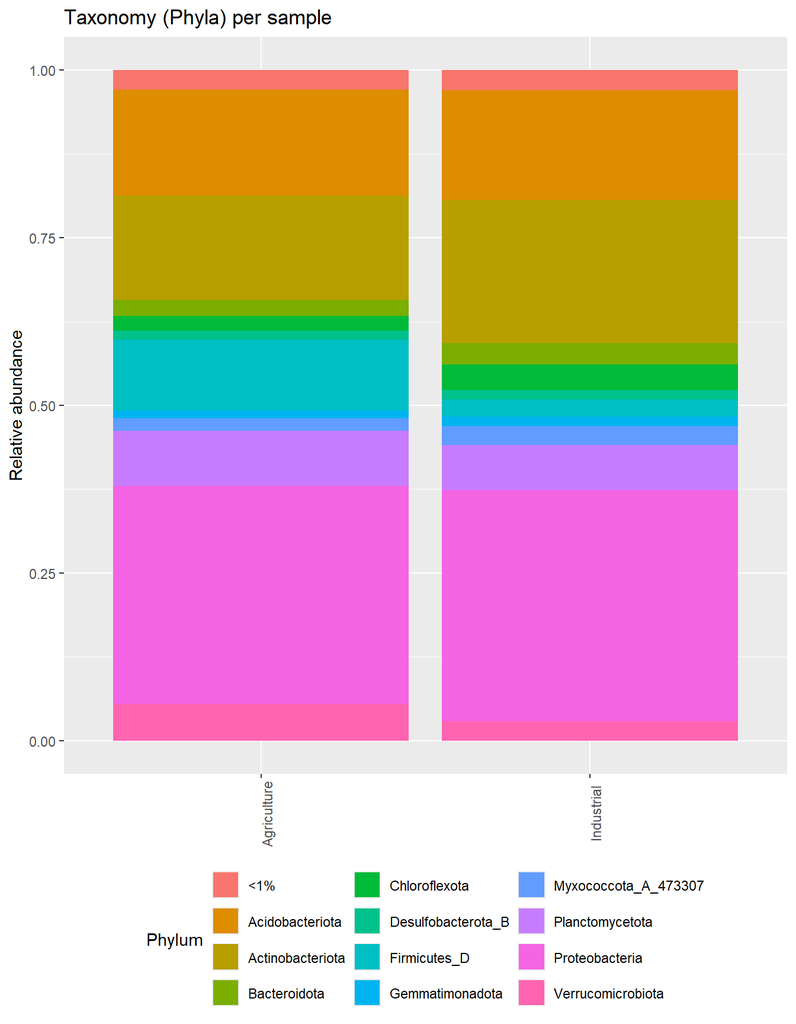

```r
# Select the cut-off (e.g. 1% of total count)
cutoff <- 0.01 * sum(MeltData.df$Abundance)

# Select low-abundant Phyla (with total counts below the cutoff)
lowAbundant <- Phyla.df[Phyla.df$Count <= cutoff,]$Phylum

# Substitute Phylum names to "<1%" for the low-abundant phyla
MeltData.df[MeltData.df$Phylum %in% lowAbundant,]$Phylum <- '<1%'

library(RColorBrewer) # ?

# Make stacked barplot
ggplot(MeltData.df, aes(x=Sample, y=Abundance, fill=Phylum)) +
  geom_bar(aes(), stat="identity", position="stack") +
  theme(legend.position="bottom") +
  ggtitle("Taxonomy (Phyla) per sample") +
  guides(fill=guide_legend(nrow=3)) +
  theme(axis.text.x = element_text(angle = 90)) +
  labs(y= "Relative abundance", x = NULL) +
  theme(legend.position = "bottom") +
  guides(fill=guide_legend(ncol=3)) +
  scale_color_brewer(palette = "Dark2") # ?
```

```r
# Clean-up
rm(landUse.phy, MeltData.df, Phyla.df, cutoff, lowAbundant)
```

# Differential abundance with ancombc2

**ANCOMBC** package implements a method for **differential abundance analysis**, which takes into account the compositionality of microbial data: https://www.nature.com/articles/s41467-020-17041-7

Like **Vegan** and **Phyloseq**, **ANCOMBC** is a very popular package, and it can directly accept the **Phyloseq** objects.

```r
detach("package:phyloseq", unload=TRUE) # unload phyloseq package (to avoid warnings from ANCOMBC)

# Lad package
library(ANCOMBC)

# Estimate differential abundances
# ~5min, multiple warnings are OK
ancom.output = ancombc2(data = BacIndAgriClassAbundNorm.phy, tax_level = "Class",
                fix_formula = "Former_landuse",
                group = "Former_landuse",
                p_adj_method = "holm", alpha = 0.05, pairwise = TRUE,
                prv_cut = 0.10, lib_cut = 1000,
                n_cl = 4, verbose = TRUE)

# Clean-up
detach("package:ANCOMBC", unload=TRUE) # unload ANCOMBC package (just in case)
```

## Extract results from ancombc2 output

The **ancombc2** output contains many components that we don’t need for the downstream analysis. We only need the **table with results**. Moreover, within this table we will only use selected **columns describing Former Landuse** (ignoring the data about intercept).

The columns that we need are:

- **taxon**: the taxa (at Class level in our case)
- **lfc_Former_landuseIndustrial**: Log Fold Change (Industrial vs Agriculture)
- **se_Former_landuseIndustrial**: Standard error for LFC
- **W_Former_landuseIndustrial**: The statistics calculated by ANCOMBC
- **p_Former_landuseIndustrial**: p-value for the statistics (w/o the multiple testing correction)
- **q_Former_landuseIndustrial**: significance after the multiple testing correction
- **diff_Former_landuseIndustrial**: Is this taxon differentially abundant ? (TRUE/FALSE)
- **passed_ss_Former_landuseIndustrial**: Has the taxon passed the additional ANCOMBC check? (TRUE/FALSE)

```r
# Extract the results table
results.df <- ancom.output$res
colnames(results.df)
```

```
##  [1] "taxon"                              "lfc_(Intercept)"                    "lfc_Former_landuseIndustrial"       "se_(Intercept)"                     "se_Former_landuseIndustrial"        "W_(Intercept)"                      "W_Former_landuseIndustrial"         "p_(Intercept)"                  …
```

```r
dim(results.df) # Taxa at Class level
```

```
## [1] 78 15
```

```r
# Select only columns that we need
all_results.df <- results.df %>%
  select(taxon, contains("Former_landuse"))
colnames(all_results.df)
```

```
## [1] "taxon"                              "lfc_Former_landuseIndustrial"       "se_Former_landuseIndustrial"        "W_Former_landuseIndustrial"         "p_Former_landuseIndustrial"         "q_Former_landuseIndustrial"         "diff_Former_landuseIndustrial"      "passed_ss_Former_landuseIndustria…
```

```r
dim(all_results.df)
```

```
## [1] 78  8
```

```r
head(all_results.df)
```

```
##              taxon lfc_Former_landuseIndustrial se_Former_landuseIndustrial W_Former_landuseIndustrial p_Former_landuseIndustrial q_Former_landuseIndustrial diff_Former_landuseIndustrial passed_ss_Former_landuseIndustrial
## 1 Verrucomicrobiae                  -0.82426018                  0.08275802                 -9.9598823               2.330449e-20               1.794446e-18                          TRUE                               TRUE
## 2             Mor1                   0.23297401                  0.10575036                  2.2030565               2.861906e-02               1.000000e+00                         FALSE                               TRUE
## 3    Phycisphaerae                   0.06663988                  0.09120842                  0.7306330               4.655774e-01               1.000000e+00                         FALSE                               TRUE
## 4   Planctomycetia                  -0.46176887                  0.08390641                 -5.5033802               8.037380e-08               5.304671e-06                          TRUE                               TRUE
## 5           B15-G4                  -0.06627643                  0.09900998                 -0.6693914               5.038787e-01               1.000000e+00                         FALSE                               TRUE
## 6          UBA8108                   0.01876799                  0.07885381                  0.2380099               8.127122e-01               1.000000e+00                         FALSE                              FALSE
```

```r
# Clean-up
rm(results.df, ancom.output)
```